# week9 15 Colinearity

kwon

2018년 7월 3일

# Chapter 15 Collinearity

## 1. Exact Collinearity

```r
gen_exact_collin_data = function(num_samples= 100){
  x1 = rnorm(n=num_samples, mean=80, sd=10)
  x2 = rnorm(n= num_samples, mean=70, sd=5)
  x3 = 2*x1 +4*x2 +3
  y = 3+ x1 + x2 + rnorm(n=num_samples, mean=0, sd=1)
  data.frame(y, x1, x2, x3)
}

set.seed(42)
exact_collin_data = gen_exact_collin_data()
head(exact_collin_data)
```

```
##          y       x1       x2       x3
## 1 170.7135 93.70958 76.00483 494.4385
## 2 152.9106 74.35302 75.22376 452.6011
## 3 152.7866 83.63128 64.98396 430.1984
## 4 170.6306 86.32863 79.24241 492.6269
## 5 152.3320 84.04268 66.66613 437.7499
## 6 151.3155 78.93875 70.52757 442.9878
```

```r
exact_collin_fit = lm(y~x1+x2+x3, data= exact_collin_data)
summary(exact_collin_fit)
```

```
##
## Call:
## lm(formula = y ~ x1 + x2 + x3, data = exact_collin_data)
##
## Residuals:
##      Min       1Q   Median       3Q      Max
## -2.57662 -0.66188 -0.08253  0.63706  2.52057
##
## Coefficients: (1 not defined because of singularities)
##             Estimate Std. Error t value Pr(>|t|)
## (Intercept) 2.957336   1.735165   1.704   0.0915 .
## x1          0.985629   0.009788 100.702   <2e-16 ***
## x2          1.017059   0.022545  45.112   <2e-16 ***
## x3                NA         NA      NA       NA
## ---
## Signif. codes:  0 '***' 0.001 '**' 0.01 '*' 0.05 '.' 0.1 ' ' 1
##
## Residual standard error: 1.014 on 97 degrees of freedom
## Multiple R-squared:  0.9923, Adjusted R-squared:  0.9921
## F-statistic:  6236 on 2 and 97 DF,  p-value: < 2.2e-16
```

`R` decides to exclude a variable, because if we attempt to find $\hat\beta$ using $(X^TX)^{-1}$, it is not possible, due to the linearly dependency in $X$. When this happens, we say there is exact collinearity in the dataset.

```r
X = cbind(1, as.matrix(exact_collin_data[,-1]))
# solve(t(X) %*% X)
```

```r
fit1 = lm(y~x1+x2, data= exact_collin_data)
fit2 = lm(y~x1+x3, data= exact_collin_data)
fit3 = lm(y~x2+x3, data= exact_collin_data)

all.equal(fitted(fit1),fitted(fit2))
```

```
## [1] TRUE
```

```r
all.equal(fitted(fit2),fitted(fit3))
```

```
## [1] TRUE
```

```r
all.equal(fitted(fit3),fitted(fit2))
```

```
## [1] TRUE
```

Their fitted values are all the same, while their estimated coefficients are wildly different.

```r
coef(fit1)
```

```
## (Intercept)          x1          x2
##   2.9573357   0.9856291   1.0170586
```

```r
coef(fit2)
```

```
## (Intercept)          x1          x3
##   2.1945418   0.4770998   0.2542647
```

```r
coef(fit3)
```

```
## (Intercept)          x2          x3
##   1.4788921  -0.9541995   0.4928145
```

The sign of $x_2$ is switched in two of the models(`fit1`, `fit3`). So only `fit1` properly expalins the relationship between the variables, `fit2` and `fit3` still predcit as well as `fit1`, despite the coefficients having little to no meaning.

## 2. Collinearity

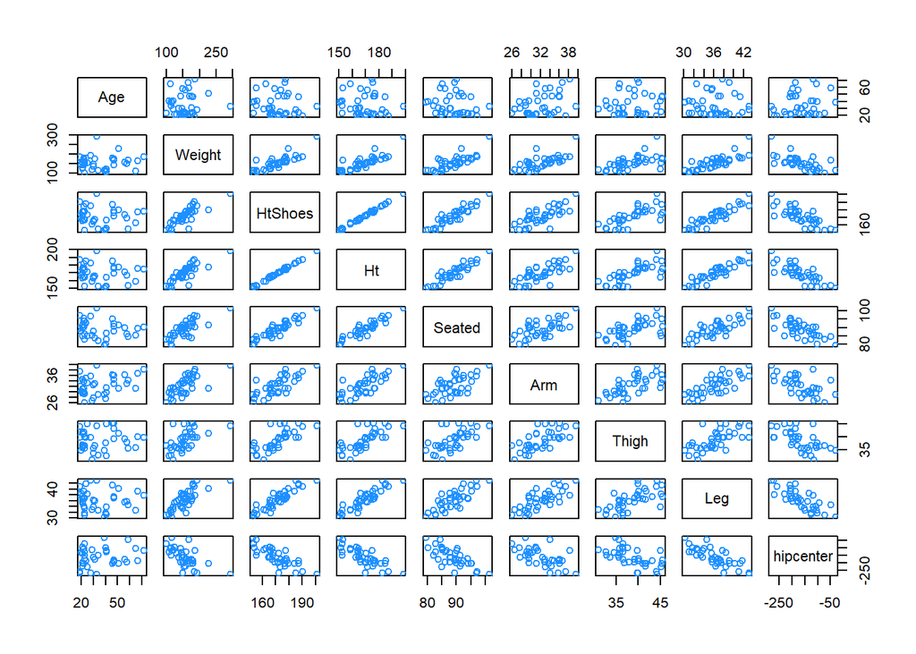

```r
library(faraway)
pairs(seatpos, col = "dodgerblue")
```

```r
round(cor(seatpos),2)
```

```
##             Age Weight HtShoes    Ht Seated   Arm Thigh   Leg hipcenter
## Age        1.00   0.08   -0.08 -0.09  -0.17  0.36  0.09 -0.04      0.21
## Weight     0.08   1.00    0.83  0.83   0.78  0.70  0.57  0.78     -0.64
## HtShoes   -0.08   0.83    1.00  1.00   0.93  0.75  0.72  0.91     -0.80
## Ht        -0.09   0.83    1.00  1.00   0.93  0.75  0.73  0.91     -0.80
## Seated    -0.17   0.78    0.93  0.93   1.00  0.63  0.61  0.81     -0.73
## Arm        0.36   0.70    0.75  0.75   0.63  1.00  0.67  0.75     -0.59
## Thigh      0.09   0.57    0.72  0.73   0.61  0.67  1.00  0.65     -0.59
## Leg       -0.04   0.78    0.91  0.91   0.81  0.75  0.65  1.00     -0.79
## hipcenter  0.21  -0.64   -0.80 -0.80  -0.73 -0.59 -0.59 -0.79      1.00
```

```r
hip_model =lm(hipcenter ~., data=seatpos)
summary(hip_model)
```

```
##
## Call:
## lm(formula = hipcenter ~ ., data = seatpos)
##
## Residuals:
##     Min      1Q  Median      3Q     Max
## -73.827 -22.833  -3.678  25.017  62.337
##
## Coefficients:
##              Estimate Std. Error t value Pr(>|t|)
## (Intercept) 436.43213  166.57162   2.620   0.0138 *
## Age           0.77572    0.57033   1.360   0.1843
## Weight        0.02631    0.33097   0.080   0.9372
## HtShoes      -2.69241    9.75304  -0.276   0.7845
## Ht            0.60134   10.12987   0.059   0.9531
## Seated        0.53375    3.76189   0.142   0.8882
## Arm          -1.32807    3.90020  -0.341   0.7359
## Thigh        -1.14312    2.66002  -0.430   0.6706
## Leg          -6.43905    4.71386  -1.366   0.1824
## ---
## Signif. codes:  0 '***' 0.001 '**' 0.01 '*' 0.05 '.' 0.1 ' ' 1
##
## Residual standard error: 37.72 on 29 degrees of freedom
## Multiple R-squared:  0.6866, Adjusted R-squared:  0.6001
## F-statistic:  7.94 on 8 and 29 DF,  p-value: 1.306e-05
```

When predictors are highly correlated, their effects on the response are lessened individually, but together they still explain a large portion of the variation of `hipcenter`. $R_j^2$ to be the proportion of observed variation in the j-th predictor explained by the other predictors.

```r
ht_shoes_model = lm(HtShoes~ . -hipcenter, data= seatpos)
summary(ht_shoes_model)
```

```
##
## Call:
## lm(formula = HtShoes ~ . - hipcenter, data = seatpos)
##
## Residuals:
##      Min       1Q   Median       3Q      Max
## -1.40812 -0.35387  0.07312  0.31358  1.55182
##
## Coefficients:
##              Estimate Std. Error t value Pr(>|t|)
## (Intercept)  0.231451   3.117889   0.074    0.941
## Age          0.014462   0.010345   1.398    0.172
## Weight      -0.002405   0.006180  -0.389    0.700
## Ht           1.001574   0.050206  19.949   <2e-16 ***
## Seated       0.048687   0.069858   0.697    0.491
## Arm         -0.022155   0.072898  -0.304    0.763
## Thigh       -0.060584   0.048551  -1.248    0.222
## Leg          0.010946   0.088220   0.124    0.902
## ---
## Signif. codes:  0 '***' 0.001 '**' 0.01 '*' 0.05 '.' 0.1 ' ' 1
##
## Residual standard error: 0.7061 on 30 degrees of freedom
## Multiple R-squared:  0.9967, Adjusted R-squared:  0.996
## F-statistic:  1313 on 7 and 30 DF,  p-value: < 2.2e-16
```

### 2.1 Variance Inflation Factor.

$$Var(\hat\beta_j) = \sigma^2C_{jj} = \sigma^2\frac{1}{1-R_j^2}
\frac{1}{S_{x_j x_j}}$$
where
$$S_{x_j x_j} = \sum({x_{ij} - \bar{x_j} })^2.$$

$$\frac{1}{1-R_j^2}$$

is called **variance inflation factor**. The VIF quantifies the effect of collinearity on the variacne of our regression estimates.

```r
vif(hip_model)
```

```
##        Age     Weight    HtShoes         Ht     Seated        Arm
##   1.997931   3.647030 307.429378 333.137832   8.951054   4.496368
##      Thigh        Leg
##   2.762886   6.694291
```

```r
set.seed(1337)
noise = rnorm(n= nrow(seatpos), mean=0, sd=5)
hip_model_noise = lm(hipcenter + noise ~ .,data=seatpos)

coef(hip_model)
```

```
##  (Intercept)          Age       Weight      HtShoes           Ht
## 436.43212823   0.77571620   0.02631308  -2.69240774   0.60134458
##       Seated          Arm        Thigh          Leg
##   0.53375170  -1.32806864  -1.14311888  -6.43904627
```

```r
coef(hip_model_noise)
```

```
##  (Intercept)          Age       Weight      HtShoes           Ht
## 415.32909380   0.76578240   0.01910958  -2.90377584  -0.12068122
##       Seated          Arm        Thigh          Leg
##   2.03241638  -1.02127944  -0.89034509  -5.61777220
```

How does collinearity effect prediction?

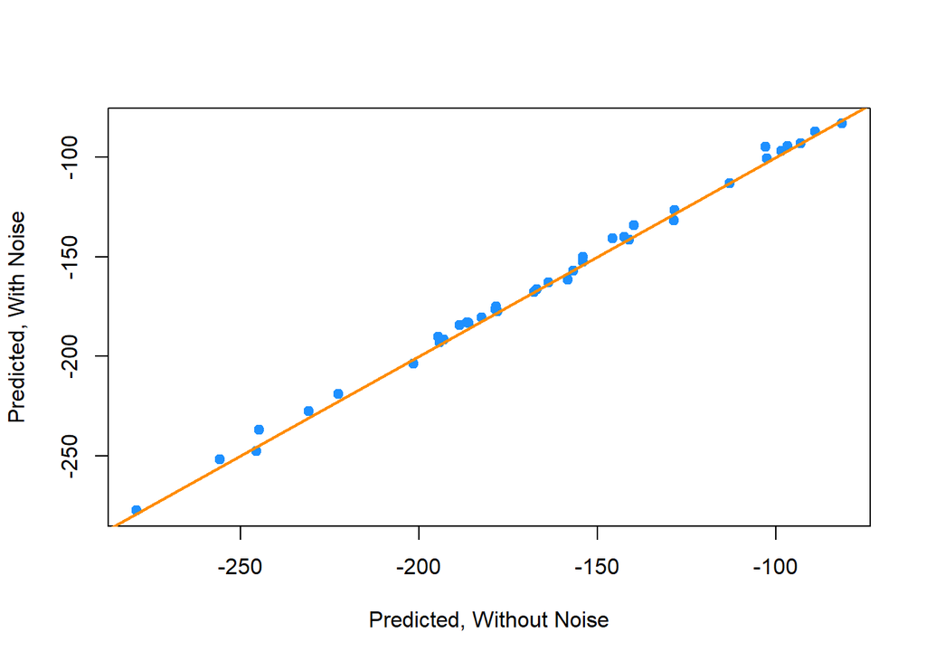

```r
plot(fitted(hip_model), fitted(hip_model_noise), col= "dodgerblue", pch =20, xlab="Predicted, Without Noise", ylab = "Predicted, With Noise", cex=1.5)
abline(a= 0 , b=1, col="darkorange", lwd=2)
```

Try smaller model

```r
hip_model_small = lm(hipcenter~Age +Arm+Ht, data= seatpos)
summary(hip_model_small)
```

```
##
## Call:
## lm(formula = hipcenter ~ Age + Arm + Ht, data = seatpos)
##
## Residuals:
##     Min      1Q  Median      3Q     Max
## -82.347 -24.745  -0.094  23.555  58.314
##
## Coefficients:
##             Estimate Std. Error t value Pr(>|t|)
## (Intercept) 493.2491   101.0724   4.880 2.46e-05 ***
## Age           0.7988     0.5111   1.563  0.12735
## Arm          -2.9385     3.5210  -0.835  0.40979
## Ht           -3.4991     0.9954  -3.515  0.00127 **
## ---
## Signif. codes:  0 '***' 0.001 '**' 0.01 '*' 0.05 '.' 0.1 ' ' 1
##
## Residual standard error: 36.12 on 34 degrees of freedom
## Multiple R-squared:  0.6631, Adjusted R-squared:  0.6333
## F-statistic:  22.3 on 3 and 34 DF,  p-value: 3.649e-08
```

```r
vif(hip_model_small)
```

```
##      Age      Arm       Ht
## 1.749943 3.996766 3.508693
```

```r
anova(hip_model_small, hip_model)
```

```
## Analysis of Variance Table
##
## Model 1: hipcenter ~ Age + Arm + Ht
## Model 2: hipcenter ~ Age + Weight + HtShoes + Ht + Seated + Arm + Thigh +
##     Leg
##   Res.Df   RSS Df Sum of Sq      F Pr(>F)
## 1     34 44354
## 2     29 41262  5    3091.9 0.4346 0.8207
```

Partial correlation coefficient of `HtShoes` and `hipcenter` with the effects of `Age`, `Arm`, and `Ht` removed

```r
ht_shoes_model_small = lm(HtShoes~Age + Arm +Ht, data=seatpos)

cor(resid(ht_shoes_model_small), resid(hip_model_small))
```

```
## [1] -0.03311061
```

Since this value is small, it means that the variation of `hipcenter` that is unexplained by `Age`, `Arm`, and `Ht` shows very little correlation with the variation of `HtShoes`. Thus, adding `HtShoes` to the model would likely be of little bnefit.

Similarly a varaible added plot visualizes these residuals agains each other.

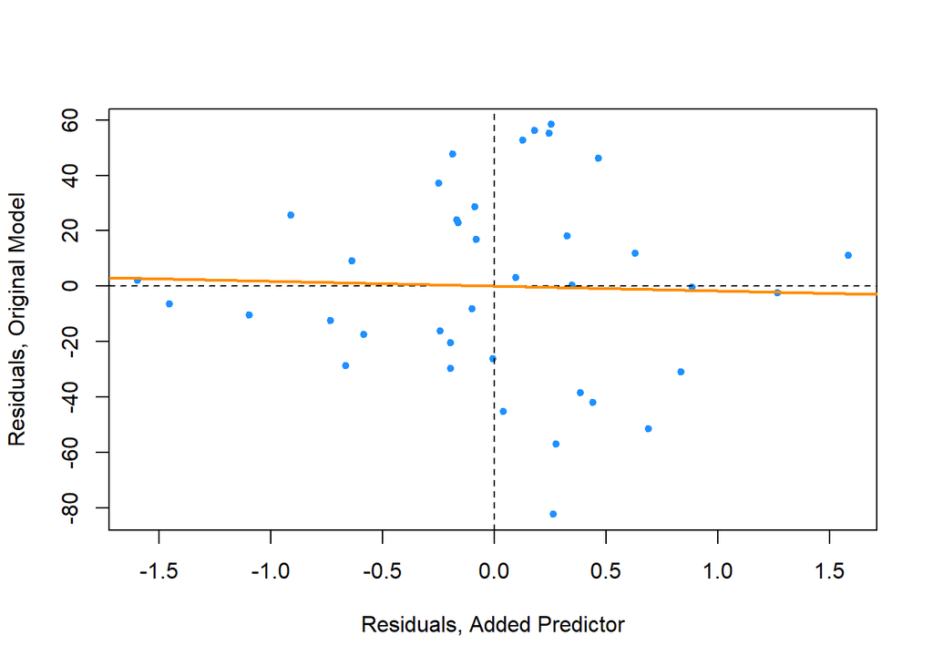

```r
plot(resid(hip_model_small)~resid(ht_shoes_model_small),
     col="dodgerblue", pch=20,
     xlab = "Residuals, Added Predictor",
     ylab = "Residuals, Original Model")
abline(h = 0, lty=2)
abline(v=0, lty=2)
abline(lm(resid(hip_model_small)~ resid(ht_shoes_model_small)), col="darkorange", lwd=2)
```

Here the variable added plot shows almost no linear relationship. Since `HtShoes`’s variation is largely expalined by the other predictors, adding ti to the model will only increase the variation of the estimates and make the model much harder to interpret.

## 3. Simulation

```r
set.seed(42)
beta_0 = 7
beta_1 = 3
beta_2 = 4
sigma = 5

sample_size =10
num_sim = 2500

x1 = c(1, 2, 3, 4, 5, 6, 7, 8, 9, 10)
x2 = c(1, 2, 3, 4, 5, 7, 6, 10, 9, 8)

c(sd(x1), sd(x2))
```

```
## [1] 3.02765 3.02765
```

```r
cor(x1, x2)
```

```
## [1] 0.9393939
```

First, we try with high collinearity.

```r
true_line_bad = beta_0 + beta_1 *x1 + beta_2*x2
beta_hat_bad = matrix(0, num_sim, 2)
mse_bad = rep(0, num_sim)
```

```r
for(s in 1:num_sim){
  y = true_line_bad + rnorm(n=sample_size, mean=0, sd=sigma)
  reg_out = lm(y~x1+x2)
  beta_hat_bad[s, ] = coef(reg_out)[-1]
  mse_bad[s] = mean(resid(reg_out)^2)
}
```

The situation without a collinearity issue.

```r
z1 = c(1, 2, 3, 4, 5, 6, 7, 8, 9, 10)
z2 = c(9, 2, 7, 4, 5, 6, 3, 8, 1, 10)
c(sd(z1), sd(z2))
```

```
## [1] 3.02765 3.02765
```

```r
cor(z1, z2)
```

```
## [1] 0.03030303
```

```r
true_line_good = beta_0 + beta_1*z1 + beta_2 * z2
beta_hat_good = matrix(0, num_sim, 2)
mse_good = rep(0, num_sim)
```

```r
for(s in 1:num_sim){
  y = true_line_good +rnorm(n=sample_size, mean=0, sd=sigma)
  reg_out = lm(y~z1+z2)
  beta_hat_good[s, ] = coef(reg_out)[-1]
  mse_good[s] = mean(resid(reg_out)^2)
}
```

The differences of the two models.

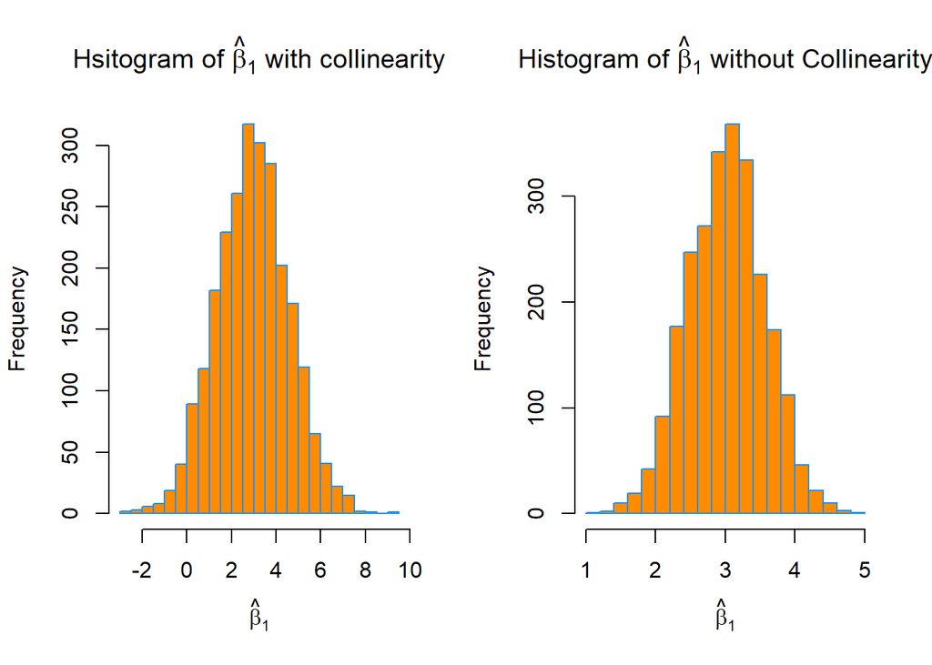

```r
par(mfrow= c(1,2))
hist(beta_hat_bad[,1],
     col="darkorange",
     border = "dodgerblue",
     main = expression("Hsitogram of " *hat(beta)[1]* " with collinearity"),
     xlab = expression(hat(beta)[1]),
     breaks=20)
hist(beta_hat_good[, 1],
     col = "darkorange",
     border = "dodgerblue",
     main = expression("Histogram of " *hat(beta)[1]* " without Collinearity"),
     xlab = expression(hat(beta)[1]),
     breaks = 20)
```

```r
mean(beta_hat_bad[,1])
```

```
## [1] 2.963325
```

```r
mean(beta_hat_good[,1])
```

```
## [1] 3.013414
```

```r
sd(beta_hat_bad[,1])
```

```
## [1] 1.633294
```

```r
sd(beta_hat_good[,1])
```

```
## [1] 0.5484684
```

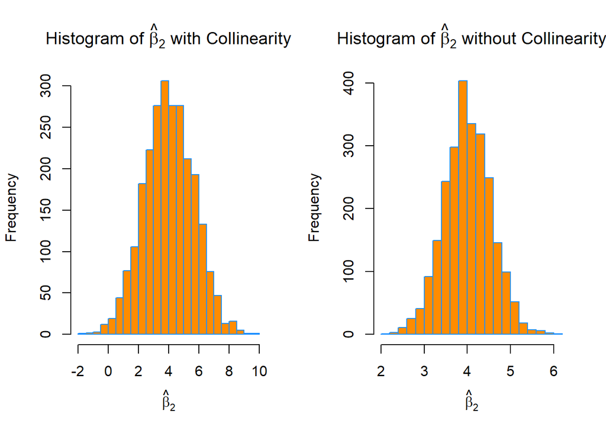

```r
par(mfrow = c(1, 2))
hist(beta_hat_bad[, 2],
     col = "darkorange",
     border = "dodgerblue",
     main = expression("Histogram of " *hat(beta)[2]* " with Collinearity"),
     xlab = expression(hat(beta)[2]),
     breaks = 20)
hist(beta_hat_good[, 2],
     col = "darkorange",
     border = "dodgerblue",
     main = expression("Histogram of " *hat(beta)[2]* " without Collinearity"),
     xlab = expression(hat(beta)[2]),
     breaks = 20)
```

Same issue with $\hat\beta_2$

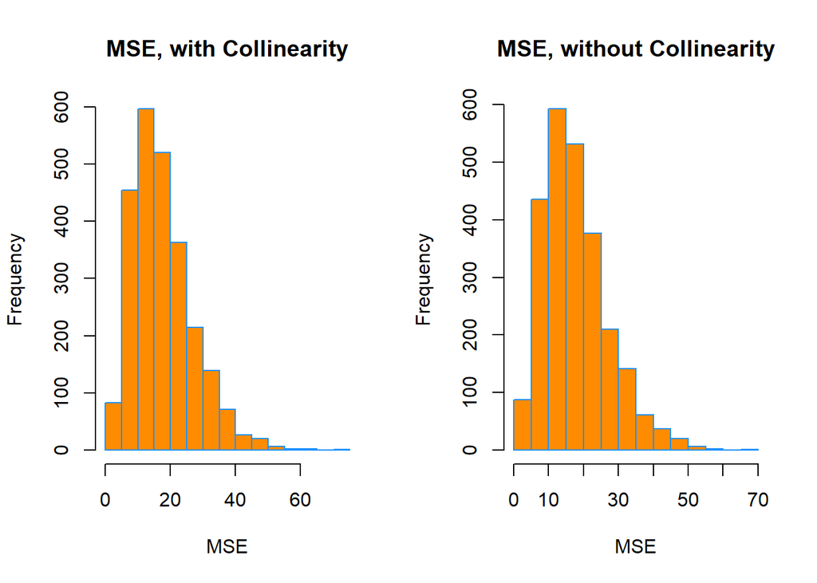

```r
par(mfrow = c(1, 2))
hist(mse_bad,
     col = "darkorange",
     border = "dodgerblue",
     main = "MSE, with Collinearity",
     xlab = "MSE")
hist(mse_good,
     col = "darkorange",
     border = "dodgerblue",
     main = "MSE, without Collinearity",
     xlab = "MSE")
```

Interestingly, in both cases, the MSE is roughly the same on average. Again, this is because collinearity effects a model’s ability to explain, but not predict.

```r
mean(mse_bad)
```

```
## [1] 17.7186
```

```r
mean(mse_good)
```

```
## [1] 17.70513
```